# The Analytics Edge (Unit 6)

Na Sai

April 20, 2015

# Quick Question

## Computing Distances

The movie “The Godfather” is in the genres action, crime, and drama, and is defined by the vector: (0,1,0,0,0,0,1,0,1,0,0,0,0,0,0,0,0,0,0)

The movie “Titanic” is in the genres action, drama, and romance, and is defined by the vector: (0,1,0,0,0,0,0,0,1,0,0,0,0,0,1,0,0,0,0)

What is the distance between “The Godfather” and “Titanic”, using euclidean distance?

```r
x1 <- c(0,1,0,0,0,0,1,0,1,0,0,0,0,0,0,0,0,0,0)
x2 <- c(0,1,0,0,0,0,0,0,1,0,0,0,0,0,1,0,0,0,0)
EucDis <- sqrt(sum((x2-x1)^2))
EucDis
```

```
## [1] 1.414214
```

## Movies Data

In this video, we’ll be downloading our dataset from the MovieLens website. Please open the following link in a new window or tab of your browser to access the data: http://files.grouplens.org/datasets/movielens/ml-100k/u.item

```r
# After following the steps in the video, load the data into R
movies = read.table("movieLens.txt", header=FALSE, sep="|",quote="\"")

str(movies)
```

```
## 'data.frame':    1682 obs. of  24 variables:
##  $ V1 : int  1 2 3 4 5 6 7 8 9 10 ...
##  $ V2 : Factor w/ 1664 levels "'Til There Was You (1997)",..: 1525 618 555 594 344 1318 1545 111 391 1240 ...
##  $ V3 : Factor w/ 241 levels "","01-Aug-1997",..: 71 71 71 71 71 71 71 71 71 182 ...
##  $ V4 : logi  NA NA NA NA NA NA ...
##  $ V5 : Factor w/ 1661 levels "","http://us.imdb.com/M/title-exact?%22Langoliers,%20The%22%20(1995)%20(mini)",..: 1430 564 504 542 309 1661 1452 102 356 1182 ...
##  $ V6 : int  0 0 0 0 0 0 0 0 0 0 ...
##  $ V7 : int  0 1 0 1 0 0 0 0 0 0 ...
##  $ V8 : int  0 1 0 0 0 0 0 0 0 0 ...
##  $ V9 : int  1 0 0 0 0 0 0 0 0 0 ...
##  $ V10: int  1 0 0 0 0 0 0 1 0 0 ...
##  $ V11: int  1 0 0 1 0 0 0 1 0 0 ...
##  $ V12: int  0 0 0 0 1 0 0 0 0 0 ...
##  $ V13: int  0 0 0 0 0 0 0 0 0 0 ...
##  $ V14: int  0 0 0 1 1 1 1 1 1 1 ...
##  $ V15: int  0 0 0 0 0 0 0 0 0 0 ...
##  $ V16: int  0 0 0 0 0 0 0 0 0 0 ...
##  $ V17: int  0 0 0 0 0 0 0 0 0 0 ...
##  $ V18: int  0 0 0 0 0 0 0 0 0 0 ...
##  $ V19: int  0 0 0 0 0 0 0 0 0 0 ...
##  $ V20: int  0 0 0 0 0 0 0 0 0 0 ...
##  $ V21: int  0 0 0 0 0 0 1 0 0 0 ...
##  $ V22: int  0 1 1 0 1 0 0 0 0 0 ...
##  $ V23: int  0 0 0 0 0 0 0 0 0 1 ...
##  $ V24: int  0 0 0 0 0 0 0 0 0 0 ...
```

```r
# Add column names
colnames(movies) = c("ID", "Title", "ReleaseDate", "VideoReleaseDate", "IMDB", "Unknown", "Action", "Adventure", "Animation", "Childrens", "Comedy", "Crime", "Documentary", "Drama", "Fantasy", "FilmNoir", "Horror", "Musical", "Mystery", "Romance", "SciFi", "Thriller", "War", "Western")

str(movies)
```

```
## 'data.frame':    1682 obs. of  24 variables:
##  $ ID              : int  1 2 3 4 5 6 7 8 9 10 ...
##  $ Title           : Factor w/ 1664 levels "'Til There Was You (1997)",..: 1525 618 555 594 344 1318 1545 111 391 1240 ...
##  $ ReleaseDate     : Factor w/ 241 levels "","01-Aug-1997",..: 71 71 71 71 71 71 71 71 71 182 ...
##  $ VideoReleaseDate: logi  NA NA NA NA NA NA ...
##  $ IMDB            : Factor w/ 1661 levels "","http://us.imdb.com/M/title-exact?%22Langoliers,%20The%22%20(1995)%20(mini)",..: 1430 564 504 542 309 1661 1452 102 356 1182 ...
##  $ Unknown         : int  0 0 0 0 0 0 0 0 0 0 ...
##  $ Action          : int  0 1 0 1 0 0 0 0 0 0 ...
##  $ Adventure       : int  0 1 0 0 0 0 0 0 0 0 ...
##  $ Animation       : int  1 0 0 0 0 0 0 0 0 0 ...
##  $ Childrens       : int  1 0 0 0 0 0 0 1 0 0 ...
##  $ Comedy          : int  1 0 0 1 0 0 0 1 0 0 ...
##  $ Crime           : int  0 0 0 0 1 0 0 0 0 0 ...
##  $ Documentary     : int  0 0 0 0 0 0 0 0 0 0 ...
##  $ Drama           : int  0 0 0 1 1 1 1 1 1 1 ...
##  $ Fantasy         : int  0 0 0 0 0 0 0 0 0 0 ...
##  $ FilmNoir        : int  0 0 0 0 0 0 0 0 0 0 ...
##  $ Horror          : int  0 0 0 0 0 0 0 0 0 0 ...
##  $ Musical         : int  0 0 0 0 0 0 0 0 0 0 ...
##  $ Mystery         : int  0 0 0 0 0 0 0 0 0 0 ...
##  $ Romance         : int  0 0 0 0 0 0 0 0 0 0 ...
##  $ SciFi           : int  0 0 0 0 0 0 1 0 0 0 ...
##  $ Thriller        : int  0 1 1 0 1 0 0 0 0 0 ...
##  $ War             : int  0 0 0 0 0 0 0 0 0 1 ...
##  $ Western         : int  0 0 0 0 0 0 0 0 0 0 ...
```

```r
# Remove unnecessary variables
movies$ID = NULL
movies$ReleaseDate = NULL
movies$VideoReleaseDate = NULL
movies$IMDB = NULL

# Remove duplicates
movies = unique(movies)

# Take a look at our data again:
str(movies)
```

```
## 'data.frame':    1664 obs. of  20 variables:
##  $ Title      : Factor w/ 1664 levels "'Til There Was You (1997)",..: 1525 618 555 594 344 1318 1545 111 391 1240 ...
##  $ Unknown    : int  0 0 0 0 0 0 0 0 0 0 ...
##  $ Action     : int  0 1 0 1 0 0 0 0 0 0 ...
##  $ Adventure  : int  0 1 0 0 0 0 0 0 0 0 ...
##  $ Animation  : int  1 0 0 0 0 0 0 0 0 0 ...
##  $ Childrens  : int  1 0 0 0 0 0 0 1 0 0 ...
##  $ Comedy     : int  1 0 0 1 0 0 0 1 0 0 ...
##  $ Crime      : int  0 0 0 0 1 0 0 0 0 0 ...
##  $ Documentary: int  0 0 0 0 0 0 0 0 0 0 ...
##  $ Drama      : int  0 0 0 1 1 1 1 1 1 1 ...
##  $ Fantasy    : int  0 0 0 0 0 0 0 0 0 0 ...
##  $ FilmNoir   : int  0 0 0 0 0 0 0 0 0 0 ...
##  $ Horror     : int  0 0 0 0 0 0 0 0 0 0 ...
##  $ Musical    : int  0 0 0 0 0 0 0 0 0 0 ...
##  $ Mystery    : int  0 0 0 0 0 0 0 0 0 0 ...
##  $ Romance    : int  0 0 0 0 0 0 0 0 0 0 ...
##  $ SciFi      : int  0 0 0 0 0 0 1 0 0 0 ...
##  $ Thriller   : int  0 1 1 0 1 0 0 0 0 0 ...
##  $ War        : int  0 0 0 0 0 0 0 0 0 1 ...
##  $ Western    : int  0 0 0 0 0 0 0 0 0 0 ...
```

```r
# How many movies are classified as comedies?
table(movies$Comedy)
```

```
##
##    0    1
## 1162  502
```

```r
table(movies$Western)
```

```
##
##    0    1
## 1637   27
```

```r
table(movies$Drama==1&movies$Romance==1)
```

```
##
## FALSE  TRUE
##  1567    97
```

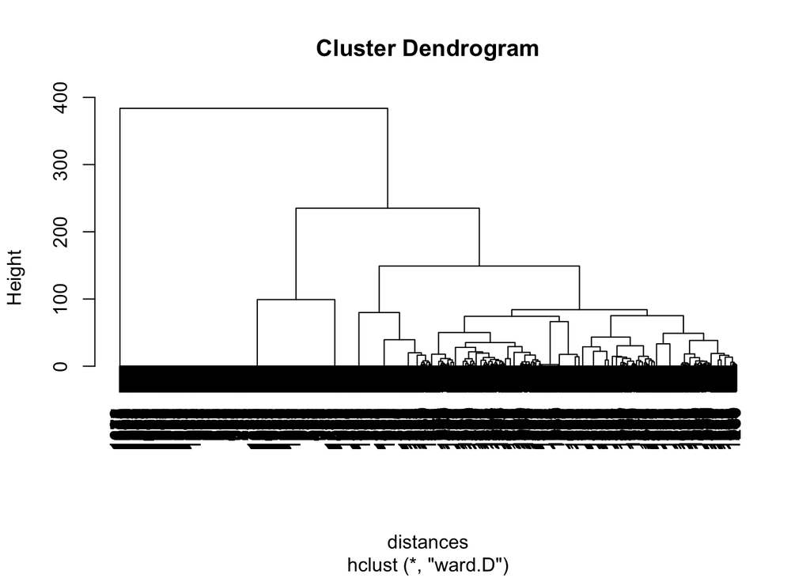

```r
# Compute distances
distances = dist(movies[2:20], method = "euclidean")

# Hierarchical clustering
clusterMovies = hclust(distances, method = "ward.D")
#clusterMovies = hclust(distances, method = "ward")

# Plot the dendrogram
plot(clusterMovies)
```

```r
# Assign points to clusters
clusterGroups = cutree(clusterMovies, k = 2)
tapply(movies$Action, clusterGroups, mean)
```

```
##         1         2
## 0.1924266 0.0000000
```

```r
tapply(movies$Comedy, clusterGroups, mean)
```

```
##         1         2
## 0.3879444 0.0000000
```

```r
tapply(movies$Adventure, clusterGroups, mean)
```

```
##         1         2
## 0.1027821 0.0000000
```

```r
tapply(movies$Romance, clusterGroups, mean)
```

```
##         1         2
## 0.1885626 0.0000000
```

```r
tapply(movies$Drama, clusterGroups, mean)
```

```
##         1         2
## 0.2673879 1.0000000
```

# Assignment 6

## 6.1

document clustering with daily kos

Document clustering, or text clustering, is a very popular application of clustering algorithms. A web search engine, like Google, often returns thousands of results for a simple query. For example, if you type the search term “jaguar” into Google, around 200 million results are returned. This makes it very difficult to browse or find relevant information, especially if the search term has multiple meanings. If we search for “jaguar”, we might be looking for information about the animal, the car, or the Jacksonville Jaguars football team.

Clustering methods can be used to automatically group search results into categories, making it easier to find relavent results. This method is used in the search engines PolyMeta and Helioid, as well as on FirstGov.gov, the official Web portal for the U.S. government. The two most common algorithms used for document clustering are Hierarchical and k-means.

In this problem, we’ll be clustering articles published on Daily Kos, an American political blog that publishes news and opinion articles written from a progressive point of view. Daily Kos was founded by Markos Moulitsas in 2002, and as of September 2014, the site had an average weekday traffic of hundreds of thousands of visits.

```r
kos<-read.csv("dailykos.csv")
str(kos)
```

```
## 'data.frame':    3430 obs. of  1545 variables:
##  $ abandon                                 : int  0 0 0 0 0 0 0 0 0 0 ...
##  $ abc                                     : int  0 0 0 0 0 0 0 0 0 0 ...
##  $ ability                                 : int  0 0 0 0 0 0 0 0 0 0 ...
##  $ abortion                                : int  0 0 0 0 0 0 0 0 0 0 ...
##  $ absolute                                : int  0 0 0 0 0 0 0 0 0 0 ...
##  $ abstain                                 : int  0 0 1 0 0 0 0 0 0 0 ...
##  $ abu                                     : int  0 0 0 0 0 0 0 0 0 0 ...
##  $ abuse                                   : int  0 0 0 0 0 0 0 0 0 0 ...
##  $ accept                                  : int  0 0 0 0 0 0 0 0 0 0 ...
##  $ access                                  : int  0 0 0 0 0 0 0 0 0 0 ...
##  $ accomplish                              : int  0 0 0 0 0 0 0 0 0 0 ...
##  $ account                                 : int  0 0 2 0 0 0 0 0 0 0 ...
##  $ accurate                                : int  0 0 0 0 0 0 0 0 0 0 ...
##  $ accusations                             : int  0 0 0 2 0 0 0 0 0 0 ...
```

[output cut: 86 more lines]

```r
# distance
kos.dist = dist(kos, method = "euclidean")

kosClusters<-hclust(kos.dist, method="ward.D")

# Select 7 clusters

kosClusters = cutree(kosClusters, k = 7)
kosClusters
```

```
##    [1] 1 1 2 3 4 1 5 6 1 6 6 2 2 6 1 3 1 1 1 1 6 6 7 2 6 5 5 1 6 1 1 3 6 6
##   [35] 2 1 6 5 3 1 5 1 1 6 2 1 6 1 1 4 4 6 6 3 1 1 1 2 3 1 1 5 6 6 1 5 6 5
##   [69] 2 1 1 1 1 6 1 4 4 3 1 2 1 1 1 1 5 3 1 5 6 2 6 1 4 1 1 6 1 6 1 2 1 6
##  [103] 1 4 4 5 1 1 6 6 6 6 2 1 1 1 1 1 1 1 1 1 1 6 6 2 1 1 2 1 1 3 1 1 1 1
##  [137] 5 1 1 6 2 5 6 1 4 1 1 2 6 6 2 1 1 1 1 5 5 6 1 4 1 1 2 1 1 5 1 6 6 4
##  [171] 3 1 5 1 2 1 6 6 1 1 1 1 3 1 4 5 2 6 6 3 6 5 1 2 3 6 3 3 6 5 3 3 2 3
##  [205] 6 5 4 6 6 1 6 2 6 1 6 6 6 6 6 2 1 3 6 6 5 5 5 1 6 3 2 3 2 1 1 1 1 1
##  [239] 4 1 1 2 6 6 3 5 1 5 6 6 3 2 3 6 6 5 6 1 6 1 4 2 1 3 4 6 4 6 3 5 6 2
##  [273] 3 1 1 1 1 6 6 1 2 1 3 1 1 4 1 3 6 6 5 2 4 1 3 1 6 6 6 1 1 2 6 3 6 1
##  [307] 6 6 6 1 2 6 6 6 1 5 1 6 1 1 2 6 6 1 3 6 1 1 6 4 2 5 1 2 6 3 1 1 1 1
##  [341] 1 6 2 1 1 3 1 6 6 6 5 1 2 1 1 1 1 6 1 1 6 4 3 1 2 3 1 6 1 1 1 6 1 3
##  [375] 7 1 2 3 1 4 1 1 1 1 1 1 6 2 1 3 1 1 3 6 3 1 1 2 5 1 3 1 6 1 4 5 5 1
##  [409] 2 1 3 3 1 4 1 6 1 5 6 6 6 2 1 5 1 6 1 1 1 1 1 1 1 3 1 2 6 5 5 6 6 6
##  [443] 3 4 6 2 6 6 2 1 1 6 7 6 7 1 5 2 6 6 1 7 1 6 1 5 1 1 2 1 1 1 6 1 1 6
##  [477] 1 1 1 4 2 4 6 1 1 1 5 4 1 1 6 1 2 3 3 1 5 1 4 3 5 6 1 1 2 1 4 3 1 5
```

[output cut: 86 more lines]

```r
#Create 7 new datasets, each containing the observations from one of the clusters.
#How many observations are in cluster 3?
cluster1 = subset(kos, kosClusters==1)
cluster2 = subset(kos, kosClusters==2)
cluster3 = subset(kos, kosClusters==3)
cluster4 = subset(kos, kosClusters==4)
cluster5 = subset(kos, kosClusters==5)
cluster6 = subset(kos, kosClusters==6)
cluster7 = subset(kos, kosClusters==7)

nrow(cluster1)
```

```
## [1] 1266
```

```r
nrow(cluster2)
```

```
## [1] 321
```

```r
nrow(cluster3)
```

```
## [1] 374
```

```r
nrow(cluster4)
```

```
## [1] 139
```

```r
nrow(cluster5)
```

```
## [1] 407
```

```r
nrow(cluster6)
```

```
## [1] 714
```

```r
nrow(cluster7)
```

```
## [1] 209
```

```r
tail(sort(colMeans(cluster1)))
```

```
##      state republican       poll   democrat      kerry       bush
##  0.7575039  0.7590837  0.9036335  0.9194313  1.0624013  1.7053712
```

```r
tail(sort(colMeans(cluster2)))
```

```
##      bush  democrat challenge      vote      poll  november
##  2.847352  2.850467  4.096573  4.398754  4.847352 10.339564
```

```r
tail(sort(colMeans(cluster3)))
```

```
##      elect    parties      state republican   democrat       bush
##   1.647059   1.665775   2.320856   2.524064   3.823529   4.406417
```

```r
tail(sort(colMeans(cluster4)))
```

```
## campaign    voter presided     poll     bush    kerry
## 1.431655 1.539568 1.625899 3.589928 7.834532 8.438849
```

```r
tail(sort(colMeans(cluster5)))
```

```
##       american       presided administration            war           iraq
##       1.090909       1.120393       1.230958       1.776413       2.427518
##           bush
##       3.941032
```

```r
tail(sort(colMeans(cluster6)))
```

```
##      race      bush     kerry     elect  democrat      poll
## 0.4579832 0.4887955 0.5168067 0.5350140 0.5644258 0.5812325
```

```r
tail(sort(colMeans(cluster7)))
```

```
## democrat    clark   edward     poll    kerry     dean
## 2.148325 2.497608 2.607656 2.765550 3.952153 5.803828
```

```r
#kmean
k= 7
set.seed(1000)
KMC = kmeans(kos, centers = k)
# Extract clusters
kosKMC = KMC$cluster
#How many observations are in Cluster 3?
table(kosKMC)
```

```
## kosKMC
##    1    2    3    4    5    6    7
##  146  144  277 2063  163  329  308
```

```r
#output the six most frequent words in each cluster,

KMC1 = subset(kos, kosKMC==1)
KMC2 = subset(kos, kosKMC==2)
KMC3 = subset(kos, kosKMC==3)
KMC4 = subset(kos, kosKMC==4)
KMC5 = subset(kos, kosKMC==5)
KMC6 = subset(kos, kosKMC==6)
KMC7 = subset(kos, kosKMC==7)

tail(sort(colMeans(KMC1)))
```

```
##          state           iraq          kerry administration       presided
##       1.609589       1.616438       1.636986       2.664384       2.767123
##           bush
##      11.431507
```

```r
tail(sort(colMeans(KMC2)))
```

```
## primaries  democrat    edward     clark     kerry      dean
##  2.319444  2.694444  2.798611  3.090278  4.979167  8.277778
```

```r
tail(sort(colMeans(KMC3)))
```

```
## administration          iraqi       american           bush            war
##       1.389892       1.610108       1.685921       2.610108       3.025271
##           iraq
##       4.093863
```

```r
tail(sort(colMeans(KMC4)))
```

```
##      elect republican      kerry       poll   democrat       bush
##  0.6010664  0.6175473  0.6495395  0.7474552  0.7891420  1.1473582
```

```r
tail(sort(colMeans(KMC5)))
```

```
##       race     senate      state    parties republican   democrat
##   2.484663   2.650307   3.521472   3.619632   4.638037   6.993865
```

```r
tail(sort(colMeans(KMC6)))
```

```
##  democrat      bush challenge      vote      poll  november
##  2.899696  2.960486  4.121581  4.446809  4.872340 10.370821
```

```r
tail(sort(colMeans(KMC7)))
```

```
## presided    voter campaign     poll     bush    kerry
## 1.324675 1.334416 1.383117 2.788961 5.970779 6.480519
```

```r
# compare KMC and H cluster groups
table(kosClusters,kosKMC)
```

```
##            kosKMC
## kosClusters    1    2    3    4    5    6    7
##           1    3   11   64 1045   32    0  111
##           2    0    0    0    0    0  320    1
##           3   85   10   42   79  126    8   24
##           4   10    5    0    0    1    0  123
##           5   48    0  171  145    3    1   39
##           6    0    2    0  712    0    0    0
##           7    0  116    0   82    1    0   10
```

## 6.2

market Segmentation For Airlines

Market segmentation is a strategy that divides a broad target market of customers into smaller, more similar groups, and then designs a marketing strategy specifically for each group. Clustering is a common technique for market segmentation since it automatically finds similar groups given a data set.

In this problem, we’ll see how clustering can be used to find similar groups of customers who belong to an airline’s frequent flyer program. The airline is trying to learn more about its customers so that it can target different customer segments with different types of mileage offers.

The file AirlinesCluster.csv contains information on 3,999 members of the frequent flyer program. This data comes from the textbook “Data Mining for Business Intelligence,” by Galit Shmueli, Nitin R. Patel, and Peter C. Bruce. For more information, see the website for the book.

```r
airlines<-read.csv("AirlinesCluster.csv")
summary(airlines)
```

```
##     Balance          QualMiles         BonusMiles       BonusTrans
##  Min.   :      0   Min.   :    0.0   Min.   :     0   Min.   : 0.0
##  1st Qu.:  18528   1st Qu.:    0.0   1st Qu.:  1250   1st Qu.: 3.0
##  Median :  43097   Median :    0.0   Median :  7171   Median :12.0
##  Mean   :  73601   Mean   :  144.1   Mean   : 17145   Mean   :11.6
##  3rd Qu.:  92404   3rd Qu.:    0.0   3rd Qu.: 23800   3rd Qu.:17.0
##  Max.   :1704838   Max.   :11148.0   Max.   :263685   Max.   :86.0
##   FlightMiles       FlightTrans     DaysSinceEnroll
##  Min.   :    0.0   Min.   : 0.000   Min.   :   2
##  1st Qu.:    0.0   1st Qu.: 0.000   1st Qu.:2330
##  Median :    0.0   Median : 0.000   Median :4096
##  Mean   :  460.1   Mean   : 1.374   Mean   :4119
##  3rd Qu.:  311.0   3rd Qu.: 1.000   3rd Qu.:5790
##  Max.   :30817.0   Max.   :53.000   Max.   :8296
```

```r
str(airlines)
```

```
## 'data.frame':    3999 obs. of  7 variables:
##  $ Balance        : int  28143 19244 41354 14776 97752 16420 84914 20856 443003 104860 ...
##  $ QualMiles      : int  0 0 0 0 0 0 0 0 0 0 ...
##  $ BonusMiles     : int  174 215 4123 500 43300 0 27482 5250 1753 28426 ...
##  $ BonusTrans     : int  1 2 4 1 26 0 25 4 43 28 ...
##  $ FlightMiles    : int  0 0 0 0 2077 0 0 250 3850 1150 ...
##  $ FlightTrans    : int  0 0 0 0 4 0 0 1 12 3 ...
##  $ DaysSinceEnroll: int  7000 6968 7034 6952 6935 6942 6994 6938 6948 6931 ...
```

```r
library(caret)
preproc = preProcess(airlines)
airlinesNorm<- predict(preproc,airlines)
summary(airlinesNorm)
```

```
##     Balance          QualMiles         BonusMiles        BonusTrans
##  Min.   :-0.7303   Min.   :-0.1863   Min.   :-0.7099   Min.   :-1.20805
##  1st Qu.:-0.5465   1st Qu.:-0.1863   1st Qu.:-0.6581   1st Qu.:-0.89568
##  Median :-0.3027   Median :-0.1863   Median :-0.4130   Median : 0.04145
##  Mean   : 0.0000   Mean   : 0.0000   Mean   : 0.0000   Mean   : 0.00000
##  3rd Qu.: 0.1866   3rd Qu.:-0.1863   3rd Qu.: 0.2756   3rd Qu.: 0.56208
##  Max.   :16.1868   Max.   :14.2231   Max.   :10.2083   Max.   : 7.74673
##   FlightMiles       FlightTrans       DaysSinceEnroll
##  Min.   :-0.3286   Min.   :-0.36212   Min.   :-1.99336
##  1st Qu.:-0.3286   1st Qu.:-0.36212   1st Qu.:-0.86607
##  Median :-0.3286   Median :-0.36212   Median :-0.01092
##  Mean   : 0.0000   Mean   : 0.00000   Mean   : 0.00000
##  3rd Qu.:-0.1065   3rd Qu.:-0.09849   3rd Qu.: 0.80960
##  Max.   :21.6803   Max.   :13.61035   Max.   : 2.02284
```

```r
max(airlinesNorm)
```

```
## [1] 21.68029
```

```r
min(airlinesNorm)
```

```
## [1] -1.993361
```

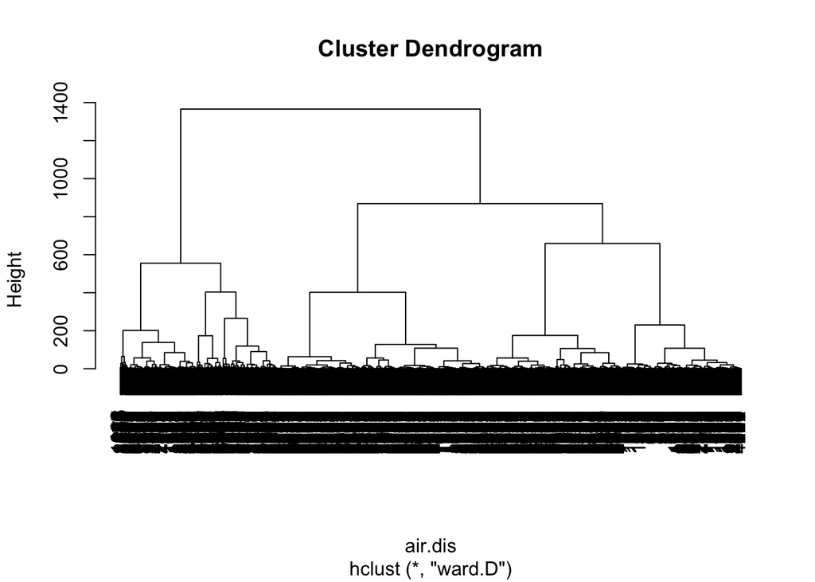

```r
air.dis <- dist(airlinesNorm,method = "euclidean")

#  Hiarchical clustering

clusterAirlines<-hclust(air.dis, method="ward.D")
plot(clusterAirlines)
```

```r
airClusters = cutree(clusterAirlines, k = 5)

#How many data points are in Cluster 1?
table(airClusters)
```

```
## airClusters
##    1    2    3    4    5
##  776  519  494  868 1342
```

```r
#use tapply to compare the average values in each of the variables
tapply(airlines$Balance, airClusters, mean)
```

```
##         1         2         3         4         5
##  57866.90 110669.27 198191.57  52335.91  36255.91
```

```r
tapply(airlines$QualMiles, airClusters, mean)
```

```
##            1            2            3            4            5
##    0.6443299 1065.9826590   30.3461538    4.8479263    2.5111773
```

```r
tapply(airlines$BonusMiles, airClusters, mean)
```

```
##         1         2         3         4         5
## 10360.124 22881.763 55795.860 20788.766  2264.788
```

```r
tapply(airlines$BonusTrans, airClusters, mean)
```

```
##         1         2         3         4         5
## 10.823454 18.229287 19.663968 17.087558  2.973174
```

```r
tapply(airlines$FlightMiles, airClusters, mean)
```

```
##          1          2          3          4          5
##   83.18428 2613.41811  327.67611  111.57373  119.32191
```

```r
tapply(airlines$FlightTrans, airClusters, mean)
```

```
##         1         2         3         4         5
## 0.3028351 7.4026975 1.0688259 0.3444700 0.4388972
```

```r
tapply(airlines$DaysSinceEnroll, airClusters, mean)
```

```
##        1        2        3        4        5
## 6235.365 4402.414 5615.709 2840.823 3060.081
```

```r
# k-means
k <- 5
set.seed(88)
airKM<- kmeans(airlines,centers = k,iter.max=1000)

#How many clusters have more than 1,000 observations?
table(airKM$cluster)
```

```
##
##    1    2    3    4    5
##  106   22 1095 2336  440
```

```r
#compare the cluster centroids to each other
airKM$centers
```

```
##     Balance QualMiles BonusMiles BonusTrans FlightMiles FlightTrans
## 1 389711.50 390.01887  51653.019  19.830189   1409.0472   4.4622642
## 2 884040.64 605.90909  56643.136  21.636364   1945.1364   6.7727273
## 3  87200.24 171.12146  25564.519  15.036530    590.6950   1.7607306
## 4  23991.14  95.81507   7809.135   8.371147    239.5497   0.7470034
## 5 186467.78 251.00000  35467.236  17.722727   1002.7545   2.7227273
##   DaysSinceEnroll
## 1        5882.321
## 2        6247.773
## 3        4420.725
## 4        3716.071
## 5        4972.057
```

```r
tapply(airlines$Balance, airKM$cluster, mean)
```

```
##         1         2         3         4         5
## 389711.50 884040.64  87200.24  23991.14 186467.78
```

```r
tapply(airlines$QualMiles, airKM$cluster, mean)
```

```
##         1         2         3         4         5
## 390.01887 605.90909 171.12146  95.81507 251.00000
```

```r
tapply(airlines$BonusMiles, airKM$cluster, mean)
```

```
##         1         2         3         4         5
## 51653.019 56643.136 25564.519  7809.135 35467.236
```

```r
tapply(airlines$BonusTrans, airKM$cluster, mean)
```

```
##         1         2         3         4         5
## 19.830189 21.636364 15.036530  8.371147 17.722727
```

```r
tapply(airlines$FlightMiles, airKM$cluster, mean)
```

```
##         1         2         3         4         5
## 1409.0472 1945.1364  590.6950  239.5497 1002.7545
```

```r
tapply(airlines$FlightTrans, airKM$cluster, mean)
```

```
##         1         2         3         4         5
## 4.4622642 6.7727273 1.7607306 0.7470034 2.7227273
```

```r
tapply(airlines$DaysSinceEnroll, airKM$cluster, mean)
```

```
##        1        2        3        4        5
## 5882.321 6247.773 4420.725 3716.071 4972.057
```

## 6.3 Predicting Stock Returns with Cluster-Then-Predict

```r
stocks<-read.csv("StocksCluster.csv")
str(stocks)
```

```
## 'data.frame':    11580 obs. of  12 variables:
##  $ ReturnJan  : num  0.0807 -0.0107 0.0477 -0.074 -0.031 ...
##  $ ReturnFeb  : num  0.0663 0.1021 0.036 -0.0482 -0.2127 ...
##  $ ReturnMar  : num  0.0329 0.1455 0.0397 0.0182 0.0915 ...
##  $ ReturnApr  : num  0.1831 -0.0844 -0.1624 -0.0247 0.1893 ...
##  $ ReturnMay  : num  0.13033 -0.3273 -0.14743 -0.00604 -0.15385 ...
##  $ ReturnJune : num  -0.0176 -0.3593 0.0486 -0.0253 -0.1061 ...
##  $ ReturnJuly : num  -0.0205 -0.0253 -0.1354 -0.094 0.3553 ...
##  $ ReturnAug  : num  0.0247 0.2113 0.0334 0.0953 0.0568 ...
##  $ ReturnSep  : num  -0.0204 -0.58 0 0.0567 0.0336 ...
##  $ ReturnOct  : num  -0.1733 -0.2671 0.0917 -0.0963 0.0363 ...
##  $ ReturnNov  : num  -0.0254 -0.1512 -0.0596 -0.0405 -0.0853 ...
##  $ PositiveDec: int  0 0 0 1 1 1 1 0 0 0 ...
```

```r
prop.table(table(stocks$PositiveDec))
```

```
##
##        0        1
## 0.453886 0.546114
```

```r
cor(stocks)
```

```
##                ReturnJan   ReturnFeb    ReturnMar    ReturnApr
## ReturnJan    1.000000000  0.06677458 -0.090496798 -0.037678006
## ReturnFeb    0.066774583  1.00000000 -0.155983263 -0.191351924
## ReturnMar   -0.090496798 -0.15598326  1.000000000  0.009726288
## ReturnApr   -0.037678006 -0.19135192  0.009726288  1.000000000
## ReturnMay   -0.044411417 -0.09552092 -0.003892789  0.063822504
## ReturnJune   0.092238307  0.16999448 -0.085905486 -0.011027752
## ReturnJuly  -0.081429765 -0.06177851  0.003374160  0.080631932
## ReturnAug   -0.022792019  0.13155979 -0.022005400 -0.051756051
## ReturnSep   -0.026437153  0.04350177  0.076518327 -0.028920972
## ReturnOct    0.142977229 -0.08732427 -0.011923758  0.048540025
## ReturnNov    0.067632333 -0.15465828  0.037323535  0.031761837
## PositiveDec  0.004728518 -0.03817318  0.022408661  0.094353528
##                ReturnMay  ReturnJune    ReturnJuly     ReturnAug
## ReturnJan   -0.044411417  0.09223831 -0.0814297650 -0.0227920187
## ReturnFeb   -0.095520920  0.16999448 -0.0617785094  0.1315597863
## ReturnMar   -0.003892789 -0.08590549  0.0033741597 -0.0220053995
## ReturnApr    0.063822504 -0.01102775  0.0806319317 -0.0517560510
## ReturnMay    1.000000000 -0.02107454  0.0908502642 -0.0331256580
## ReturnJune  -0.021074539  1.00000000 -0.0291525996  0.0107105260
## ReturnJuly   0.090850264 -0.02915260  1.0000000000  0.0007137558
## ReturnAug   -0.033125658  0.01071053  0.0007137558  1.0000000000
## ReturnSep    0.021962862  0.04474727  0.0689478037  0.0007407139
## ReturnOct    0.017166728 -0.02263599 -0.0547089088 -0.0755945614
## ReturnNov    0.048046590 -0.06527054 -0.0483738369 -0.1164890345
## PositiveDec  0.058201934  0.02340975  0.0743642097  0.0041669657
##                 ReturnSep   ReturnOct   ReturnNov  PositiveDec
## ReturnJan   -0.0264371526  0.14297723  0.06763233  0.004728518
## ReturnFeb    0.0435017706 -0.08732427 -0.15465828 -0.038173184
## ReturnMar    0.0765183267 -0.01192376  0.03732353  0.022408661
## ReturnApr   -0.0289209718  0.04854003  0.03176184  0.094353528
## ReturnMay    0.0219628623  0.01716673  0.04804659  0.058201934
## ReturnJune   0.0447472692 -0.02263599 -0.06527054  0.023409745
## ReturnJuly   0.0689478037 -0.05470891 -0.04837384  0.074364210
## ReturnAug    0.0007407139 -0.07559456 -0.11648903  0.004166966
## ReturnSep    1.0000000000 -0.05807924 -0.01971980  0.041630286
## ReturnOct   -0.0580792362  1.00000000  0.19167279 -0.052574956
## ReturnNov   -0.0197197998  0.19167279  1.00000000 -0.062346556
## PositiveDec  0.0416302863 -0.05257496 -0.06234656  1.000000000
```

```r
cor<-cor(stocks[c(1:11)], use="pairwise")

# find maximum cor between two variables
sort(cor)
```

```
##   [1] -0.1913519239 -0.1913519239 -0.1559832630 -0.1559832630 -0.1546582815
##   [6] -0.1546582815 -0.1164890345 -0.1164890345 -0.0955209197 -0.0955209197
##  [11] -0.0904967978 -0.0904967978 -0.0873242672 -0.0873242672 -0.0859054862
##  [16] -0.0859054862 -0.0814297650 -0.0814297650 -0.0755945614 -0.0755945614
##  [21] -0.0652705413 -0.0652705413 -0.0617785094 -0.0617785094 -0.0580792362
##  [26] -0.0580792362 -0.0547089088 -0.0547089088 -0.0517560510 -0.0517560510
##  [31] -0.0483738369 -0.0483738369 -0.0444114168 -0.0444114168 -0.0376780060
##  [36] -0.0376780060 -0.0331256580 -0.0331256580 -0.0291525996 -0.0291525996
##  [41] -0.0289209718 -0.0289209718 -0.0264371526 -0.0264371526 -0.0227920187
##  [46] -0.0227920187 -0.0226359936 -0.0226359936 -0.0220053995 -0.0220053995
##  [51] -0.0210745388 -0.0210745388 -0.0197197998 -0.0197197998 -0.0119237577
##  [56] -0.0119237577 -0.0110277522 -0.0110277522 -0.0038927894 -0.0038927894
##  [61]  0.0007137558  0.0007137558  0.0007407139  0.0007407139  0.0033741597
##  [66]  0.0033741597  0.0097262876  0.0097262876  0.0107105260  0.0107105260
##  [71]  0.0171667279  0.0171667279  0.0219628623  0.0219628623  0.0317618366
##  [76]  0.0317618366  0.0373235349  0.0373235349  0.0435017706  0.0435017706
##  [81]  0.0447472692  0.0447472692  0.0480465902  0.0480465902  0.0485400254
##  [86]  0.0485400254  0.0638225039  0.0638225039  0.0667745831  0.0667745831
##  [91]  0.0676323333  0.0676323333  0.0689478037  0.0689478037  0.0765183267
##  [96]  0.0765183267  0.0806319317  0.0806319317  0.0908502642  0.0908502642
## [101]  0.0922383068  0.0922383068  0.1315597863  0.1315597863  0.1429772286
## [106]  0.1429772286  0.1699944833  0.1699944833  0.1916727856  0.1916727856
## [111]  1.0000000000  1.0000000000  1.0000000000  1.0000000000  1.0000000000
## [116]  1.0000000000  1.0000000000  1.0000000000  1.0000000000  1.0000000000
## [121]  1.0000000000
```

```r
# Which month (from January through November) has the largest mean return across all observations in the dataset?
summary(stocks)
```

```
##    ReturnJan            ReturnFeb           ReturnMar
##  Min.   :-0.7616205   Min.   :-0.690000   Min.   :-0.712994
##  1st Qu.:-0.0691663   1st Qu.:-0.077748   1st Qu.:-0.046389
##  Median : 0.0009965   Median :-0.010626   Median : 0.009878
##  Mean   : 0.0126316   Mean   :-0.007605   Mean   : 0.019402
##  3rd Qu.: 0.0732606   3rd Qu.: 0.043600   3rd Qu.: 0.077066
##  Max.   : 3.0683060   Max.   : 6.943694   Max.   : 4.008621
##    ReturnApr           ReturnMay          ReturnJune
##  Min.   :-0.826503   Min.   :-0.92207   Min.   :-0.717920
##  1st Qu.:-0.054468   1st Qu.:-0.04640   1st Qu.:-0.063966
##  Median : 0.009059   Median : 0.01293   Median :-0.000880
##  Mean   : 0.026308   Mean   : 0.02474   Mean   : 0.005938
##  3rd Qu.: 0.085338   3rd Qu.: 0.08396   3rd Qu.: 0.061566
##  Max.   : 2.528827   Max.   : 6.93013   Max.   : 4.339713
##    ReturnJuly           ReturnAug           ReturnSep
##  Min.   :-0.7613096   Min.   :-0.726800   Min.   :-0.839730
##  1st Qu.:-0.0731917   1st Qu.:-0.046272   1st Qu.:-0.074648
##  Median :-0.0008047   Median : 0.007205   Median :-0.007616
##  Mean   : 0.0030509   Mean   : 0.016198   Mean   :-0.014721
##  3rd Qu.: 0.0718205   3rd Qu.: 0.070783   3rd Qu.: 0.049476
##  Max.   : 2.5500000   Max.   : 3.626609   Max.   : 5.863980
##    ReturnOct           ReturnNov          PositiveDec
##  Min.   :-0.685504   Min.   :-0.747171   Min.   :0.0000
##  1st Qu.:-0.070915   1st Qu.:-0.054890   1st Qu.:0.0000
##  Median : 0.002115   Median : 0.008522   Median :1.0000
##  Mean   : 0.005651   Mean   : 0.011387   Mean   :0.5461
##  3rd Qu.: 0.074542   3rd Qu.: 0.076576   3rd Qu.:1.0000
##  Max.   : 5.665138   Max.   : 3.271676   Max.   :1.0000
```

```r
library(caTools)
set.seed(144)
spl = sample.split(stocks$PositiveDec, SplitRatio = 0.7)

stocksTrain = subset(stocks, spl == TRUE)

stocksTest = subset(stocks, spl == FALSE)

#log model
StocksModel <- glm(PositiveDec~.,data = stocksTrain,family=binomial)
stocksTrain.pred<-predict(StocksModel,newdata = stocksTrain,type="response")
tbl <- table(stocksTrain$PositiveDec,stocksTrain.pred>=0.5)
tbl
```

```
##
##     FALSE TRUE
##   0   990 2689
##   1   787 3640
```

```r
acc<-sum(diag(tbl))/sum(tbl)
acc
```

```
## [1] 0.5711818
```

```r
# testset
stocksTest.pred<-predict(StocksModel,newdata = stocksTest,type="response")
tbl <- table(stocksTest$PositiveDec,stocksTest.pred>=0.5)
tbl
```

```
##
##     FALSE TRUE
##   0   417 1160
##   1   344 1553
```

```r
acc<-sum(diag(tbl))/sum(tbl)
acc
```

```
## [1] 0.5670697
```

```r
#baseline
tbl<-table(stocksTest$PositiveDec)
acc.base<-tbl[2]/sum(tbl)
acc.base
```

```
##         1
## 0.5460564
```

```r
# clustering stocks
limitedTrain = stocksTrain

limitedTrain$PositiveDec = NULL

limitedTest = stocksTest

limitedTest$PositiveDec = NULL

# normalize by the mean and sd of the variables in the training set
library(caret)

preproc = preProcess(limitedTrain)

normTrain = predict(preproc, limitedTrain)

normTest = predict(preproc, limitedTest)

summary(normTrain)
```

```
##    ReturnJan          ReturnFeb          ReturnMar
##  Min.   :-4.57682   Min.   :-3.43004   Min.   :-4.54609
##  1st Qu.:-0.48271   1st Qu.:-0.35589   1st Qu.:-0.40758
##  Median :-0.07055   Median :-0.01875   Median :-0.05778
##  Mean   : 0.00000   Mean   : 0.00000   Mean   : 0.00000
##  3rd Qu.: 0.35898   3rd Qu.: 0.25337   3rd Qu.: 0.36106
##  Max.   :18.06234   Max.   :34.92751   Max.   :24.77296
##    ReturnApr         ReturnMay          ReturnJune
##  Min.   :-5.0227   Min.   :-4.96759   Min.   :-4.82957
##  1st Qu.:-0.4757   1st Qu.:-0.43045   1st Qu.:-0.45602
##  Median :-0.1104   Median :-0.06983   Median :-0.04354
##  Mean   : 0.0000   Mean   : 0.00000   Mean   : 0.00000
##  3rd Qu.: 0.3400   3rd Qu.: 0.35906   3rd Qu.: 0.37273
##  Max.   :14.6959   Max.   :42.69158   Max.   :10.84515
##    ReturnJuly         ReturnAug          ReturnSep
##  Min.   :-5.19139   Min.   :-5.60378   Min.   :-5.47078
##  1st Qu.:-0.51832   1st Qu.:-0.47163   1st Qu.:-0.39604
##  Median :-0.02372   Median :-0.07393   Median : 0.04767
##  Mean   : 0.00000   Mean   : 0.00000   Mean   : 0.00000
##  3rd Qu.: 0.47735   3rd Qu.: 0.39967   3rd Qu.: 0.42287
##  Max.   :17.33975   Max.   :27.14273   Max.   :39.05435
##    ReturnOct          ReturnNov
##  Min.   :-3.53719   Min.   :-4.31684
##  1st Qu.:-0.42176   1st Qu.:-0.43564
##  Median :-0.01891   Median :-0.01878
##  Mean   : 0.00000   Mean   : 0.00000
##  3rd Qu.: 0.37451   3rd Qu.: 0.42560
##  Max.   :31.25996   Max.   :17.18255
```

```r
summary(normTest)
```

```
##    ReturnJan           ReturnFeb           ReturnMar
##  Min.   :-3.743836   Min.   :-3.251044   Min.   :-4.07731
##  1st Qu.:-0.485690   1st Qu.:-0.348951   1st Qu.:-0.40662
##  Median :-0.066856   Median :-0.006860   Median :-0.05674
##  Mean   :-0.000419   Mean   :-0.003862   Mean   : 0.00583
##  3rd Qu.: 0.357729   3rd Qu.: 0.264647   3rd Qu.: 0.35653
##  Max.   : 8.412973   Max.   : 9.552365   Max.   : 9.00982
##    ReturnApr          ReturnMay          ReturnJune
##  Min.   :-4.47865   Min.   :-5.84445   Min.   :-4.73628
##  1st Qu.:-0.51121   1st Qu.:-0.43819   1st Qu.:-0.44968
##  Median :-0.11414   Median :-0.05346   Median :-0.02678
##  Mean   :-0.03638   Mean   : 0.02651   Mean   : 0.04315
##  3rd Qu.: 0.32742   3rd Qu.: 0.42290   3rd Qu.: 0.43010
##  Max.   : 6.84589   Max.   : 7.21362   Max.   :29.00534
##    ReturnJuly          ReturnAug          ReturnSep
##  Min.   :-5.201454   Min.   :-4.62097   Min.   :-3.57222
##  1st Qu.:-0.512039   1st Qu.:-0.51546   1st Qu.:-0.38067
##  Median :-0.026576   Median :-0.10277   Median : 0.08215
##  Mean   : 0.006016   Mean   :-0.04973   Mean   : 0.02939
##  3rd Qu.: 0.457193   3rd Qu.: 0.38781   3rd Qu.: 0.45847
##  Max.   :12.790901   Max.   : 6.66889   Max.   : 7.09106
##    ReturnOct           ReturnNov
##  Min.   :-3.807577   Min.   :-4.881463
##  1st Qu.:-0.393856   1st Qu.:-0.396764
##  Median : 0.006783   Median :-0.002337
##  Mean   : 0.029672   Mean   : 0.017128
##  3rd Qu.: 0.419005   3rd Qu.: 0.424617
##  Max.   : 7.428466   Max.   :21.007786
```

```r
set.seed(144)
k = 3

km = kmeans(normTrain, centers = k)
table(km$clusters)
```

```
## < table of extent 0 >
```

```r
# Extract clusters
trainKMC= km$cluster
table(trainKMC)
```

```
## trainKMC
##    1    2    3
## 3157 4696  253
```

```r
# obtain training set and testing set cluster assignments for our observations
library(flexclust)
km.kcca = as.kcca(km, normTrain)

clusterTrain = predict(km.kcca)

clusterTest = predict(km.kcca, newdata=normTest)

#How many test-set observations were assigned to Cluster 2?
table(clusterTest)
```

```
## clusterTest
##    1    2    3
## 1298 2080   96
```

```r
# build data frames stocksTrain1, stocksTrain2, and stocksTrain3 containing the elements in the stocksTrain data frame assigned to clusters 1, 2, and 3, respectively

stocksTrain1 = subset(stocksTrain,clusterTrain==1)
stocksTrain2 = subset(stocksTrain,clusterTrain==2)
stocksTrain3 = subset(stocksTrain,clusterTrain==3)
summary(stocksTrain1)
```

```
##    ReturnJan          ReturnFeb          ReturnMar
##  Min.   :-0.76162   Min.   :-0.69000   Min.   :-0.57320
##  1st Qu.:-0.13078   1st Qu.:-0.10133   1st Qu.:-0.04280
##  Median :-0.05500   Median :-0.02637   Median : 0.01957
##  Mean   :-0.06387   Mean   :-0.03716   Mean   : 0.04041
##  3rd Qu.: 0.01217   3rd Qu.: 0.02852   3rd Qu.: 0.09770
##  Max.   : 0.56593   Max.   : 0.93548   Max.   : 4.00862
##    ReturnApr          ReturnMay          ReturnJune
##  Min.   :-0.50685   Min.   :-0.50913   Min.   :-0.71792
##  1st Qu.:-0.02956   1st Qu.:-0.01801   1st Qu.:-0.09592
##  Median : 0.03871   Median : 0.04065   Median :-0.02564
##  Mean   : 0.07219   Mean   : 0.06614   Mean   :-0.03187
##  3rd Qu.: 0.13628   3rd Qu.: 0.12357   3rd Qu.: 0.03406
##  Max.   : 2.52883   Max.   : 6.93013   Max.   : 0.68342
##    ReturnJuly          ReturnAug          ReturnSep
##  Min.   :-0.440529   Min.   :-0.72680   Min.   :-0.839730
##  1st Qu.: 0.005708   1st Qu.:-0.03639   1st Qu.:-0.073819
##  Median : 0.071535   Median : 0.01695   Median :-0.006000
##  Mean   : 0.088774   Mean   : 0.02874   Mean   :-0.007685
##  3rd Qu.: 0.151613   3rd Qu.: 0.08417   3rd Qu.: 0.059091
##  Max.   : 2.550000   Max.   : 0.82823   Max.   : 0.994012
##    ReturnOct          ReturnNov         PositiveDec
##  Min.   :-0.62163   Min.   :-0.65952   Min.   :0.0000
##  1st Qu.:-0.13416   1st Qu.:-0.10591   1st Qu.:0.0000
##  Median :-0.04452   Median :-0.02389   Median :1.0000
##  Mean   :-0.05739   Mean   :-0.03669   Mean   :0.6025
##  3rd Qu.: 0.02530   3rd Qu.: 0.03828   3rd Qu.:1.0000
##  Max.   : 0.98473   Max.   : 0.76707   Max.   :1.0000
```

```r
summary(stocksTrain2)
```

```
##    ReturnJan          ReturnFeb          ReturnMar
##  Min.   :-0.53125   Min.   :-0.65881   Min.   :-0.585567
##  1st Qu.:-0.02484   1st Qu.:-0.06422   1st Qu.:-0.043029
##  Median : 0.02704   Median :-0.00625   Median : 0.006702
##  Mean   : 0.05733   Mean   :-0.01564   Mean   : 0.012384
##  3rd Qu.: 0.10653   3rd Qu.: 0.04225   3rd Qu.: 0.067353
##  Max.   : 3.06831   Max.   : 0.71429   Max.   : 1.144144
##    ReturnApr           ReturnMay            ReturnJune
##  Min.   :-0.688576   Min.   :-0.7023529   Min.   :-0.648021
##  1st Qu.:-0.058586   1st Qu.:-0.0557004   1st Qu.:-0.044461
##  Median :-0.001394   Median : 0.0002697   Median : 0.005714
##  Mean   : 0.007330   Mean   : 0.0025419   Mean   : 0.010623
##  3rd Qu.: 0.061369   3rd Qu.: 0.0555556   3rd Qu.: 0.066032
##  Max.   : 1.682292   Max.   : 0.9431818   Max.   : 0.800000
##    ReturnJuly         ReturnAug           ReturnSep
##  Min.   :-0.75983   Min.   :-0.600664   Min.   :-0.674834
##  1st Qu.:-0.10687   1st Qu.:-0.049840   1st Qu.:-0.069820
##  Median :-0.03447   Median : 0.001883   Median :-0.009388
##  Mean   :-0.05110   Mean   : 0.001260   Mean   :-0.017565
##  3rd Qu.: 0.01487   3rd Qu.: 0.054545   3rd Qu.: 0.041167
##  Max.   : 0.68695   Max.   : 0.770000   Max.   : 5.863980
##    ReturnOct          ReturnNov         PositiveDec
##  Min.   :-0.62774   Min.   :-0.42958   Min.   :0.0000
##  1st Qu.:-0.02301   1st Qu.:-0.01952   1st Qu.:0.0000
##  Median : 0.02692   Median : 0.03063   Median :1.0000
##  Mean   : 0.05209   Mean   : 0.05388   Mean   :0.5141
##  3rd Qu.: 0.10376   3rd Qu.: 0.10236   3rd Qu.:1.0000
##  Max.   : 5.66514   Max.   : 2.67788   Max.   :1.0000
```

```r
summary(stocksTrain3)
```

```
##    ReturnJan          ReturnFeb         ReturnMar
##  Min.   :-0.59918   Min.   :-0.5506   Min.   :-0.71299
##  1st Qu.:-0.03824   1st Qu.: 0.1476   1st Qu.:-0.28423
##  Median : 0.08344   Median : 0.3653   Median :-0.14365
##  Mean   : 0.13826   Mean   : 0.5177   Mean   :-0.12149
##  3rd Qu.: 0.24519   3rd Qu.: 0.7294   3rd Qu.: 0.02949
##  Max.   : 1.96402   Max.   : 6.9437   Max.   : 1.02903
##    ReturnApr          ReturnMay           ReturnJune
##  Min.   :-0.82650   Min.   :-0.780211   Min.   :-0.4402
##  1st Qu.:-0.30692   1st Qu.:-0.261194   1st Qu.: 0.1086
##  Median :-0.11461   Median :-0.122237   Median : 0.2846
##  Mean   :-0.13443   Mean   :-0.121190   Mean   : 0.3288
##  3rd Qu.: 0.01205   3rd Qu.:-0.005882   3rd Qu.: 0.4924
##  Max.   : 0.83333   Max.   : 0.962712   Max.   : 1.6251
##    ReturnJuly         ReturnAug          ReturnSep
##  Min.   :-0.72962   Min.   :-0.49880   Min.   :-0.66055
##  1st Qu.:-0.17831   1st Qu.: 0.04408   1st Qu.:-0.21015
##  Median :-0.08607   Median : 0.16279   Median :-0.09094
##  Mean   :-0.06997   Mean   : 0.20056   Mean   :-0.09225
##  3rd Qu.: 0.02304   3rd Qu.: 0.33798   3rd Qu.: 0.02918
##  Max.   : 0.88000   Max.   : 3.62661   Max.   : 1.02547
##    ReturnOct           ReturnNov         PositiveDec
##  Min.   :-0.636536   Min.   :-0.57523   Min.   :0.0000
##  1st Qu.:-0.243810   1st Qu.:-0.34287   1st Qu.:0.0000
##  Median :-0.116087   Median :-0.21673   Median :0.0000
##  Mean   :-0.121221   Mean   :-0.20287   Mean   :0.4387
##  3rd Qu.: 0.004615   3rd Qu.:-0.09758   3rd Qu.:1.0000
##  Max.   : 0.400000   Max.   : 0.57982   Max.   :1.0000
```

```r
stocksTest1 = subset(stocksTest,clusterTest==1)
stocksTest2 = subset(stocksTest,clusterTest==2)
stocksTest3 = subset(stocksTest,clusterTest==3)

# Build logistic regression models StocksModel1, StocksModel2, and StocksModel3, which predict PositiveDec using all the other variables as independent variables

StocksModel1<- glm(PositiveDec~.,data = stocksTrain1,family = binomial)
StocksModel2<- glm(PositiveDec~.,data = stocksTrain2,family = binomial)
StocksModel3<- glm(PositiveDec~.,data = stocksTrain3,family = binomial)


StocksModel1$coef
```

```
## (Intercept)   ReturnJan   ReturnFeb   ReturnMar   ReturnApr   ReturnMay
##  0.17223985  0.02498357 -0.37207369  0.59554957  1.19047752  0.30420906
##  ReturnJune  ReturnJuly   ReturnAug   ReturnSep   ReturnOct   ReturnNov
## -0.01165375  0.19769226  0.51272941  0.58832685 -1.02253506 -0.74847186
```

```r
StocksModel2$coef
```

```
## (Intercept)   ReturnJan   ReturnFeb   ReturnMar   ReturnApr   ReturnMay
##   0.1029318   0.8845148   0.3176221  -0.3797811   0.4929105   0.8965492
##  ReturnJune  ReturnJuly   ReturnAug   ReturnSep   ReturnOct   ReturnNov
##   1.5008787   0.7831487  -0.2448602   0.7368522  -0.2775631  -0.7874737
```

```r
StocksModel3$coef
```

```
##  (Intercept)    ReturnJan    ReturnFeb    ReturnMar    ReturnApr
## -0.181895809 -0.009789345 -0.046883260  0.674179495  1.281466189
##    ReturnMay   ReturnJune   ReturnJuly    ReturnAug    ReturnSep
##  0.762511555  0.329433917  0.774164370  0.982605385  0.363806823
##    ReturnOct    ReturnNov
##  0.782242086 -0.873752144
```

```r
# Using StocksModel1, make test-set predictions called PredictTest1 on the data frame stocksTest1.
PredictTest1 <- predict(StocksModel1,newdata = stocksTest1,type = "response")
PredictTest2 <- predict(StocksModel2,newdata = stocksTest2,type = "response")
PredictTest3 <- predict(StocksModel3,newdata = stocksTest3,type = "response")

tbl1 <- table(stocksTest1$PositiveDec,PredictTest1>=0.5)
acc1<-sum(diag(tbl1))/sum(tbl1)
acc1
```

```
## [1] 0.6194145
```

```r
tbl2 <- table(stocksTest2$PositiveDec,PredictTest2>=0.5)
acc2<-sum(diag(tbl2))/sum(tbl2)
acc2
```

```
## [1] 0.5504808
```

```r
tbl3 <- table(stocksTest3$PositiveDec,PredictTest3>=0.5)
acc3<-sum(diag(tbl3))/sum(tbl3)
acc3
```

```
## [1] 0.6458333
```

```r
# overall test set accuracy

AllPredictions = c(PredictTest1, PredictTest2, PredictTest3)
AllOutcomes = c(stocksTest1$PositiveDec, stocksTest2$PositiveDec, stocksTest3$PositiveDec)
tbl<-table(AllOutcomes,AllPredictions>=0.5)
acc<-sum(diag(tbl))/sum(tbl)
acc
```

```
## [1] 0.5788716
```